$$ \newcommand\de{\mathrel{\bullet\mkern-3mu{\rightarrow}}} \newcommand\ue{\mathrel{\bullet\mkern-2mu{-}\mkern-3mu\bullet}} $$

# Introduction to (Social) Network Analysis in R

Dr Griffith Rees

08/04/2020

# 1 (Social) Network Data

Today we’re going to demonstrate simple ways of loading network data, visualisation, analysing structure, and showing how this can help answer research questions.

So a recurring point I’ll make today is that there are lots of systems that can be represented as a network. Perhaps you’re interested in **social** networks like twitter (Murthy 2012), but there are other types of networks that could be of interest (Tero et al. 2010)?

[video not shown]

## 1.1 What is a Network?

A network is a way of representing how things are connected (or not). They can be social (who tweets to who), economic (which companies employ which people), engineering (which parts were used in each product) etc. The representing of these connetions is a network–also call a graph in mathematics, (confusing eh?)–and in the social sciences it’s a tool, often applied to help quantiatively (and sometimes qualitatively) answer research questions (Heath, Fuller, and Johnston 2009).

## 1.2 Installing `R` and `igraph`

We’re going to focus on the `igraph` `R` package today. There are *many* other options but `igraph` is a fairly comprehensive package for getting started. If you’re looking to go beyond what we cover today, I recommend looking through the `igraph` documentation for your particular interests before trying the other packages, and feel free to email me griffith.rees@sheffield.ac.uk if you’ve got questions. Please ask *detailed* questions, demonstrating what you’ve trying to do and what you’ve tried so far so I can efficiently reply.

For those that have got `igraph` installed feel free to continue further down this handout to play around with the data.

Everyone else: please download `RStudio` from https://rstudio.com/products/rstudio/download/#download.

It should fit your operating system automatically (Windows, Linux or Mac). If you’re not seeing an option (possibly old versions of Windows, macOS, or unusual Linux distributions) message me.

Please fill in the survey when you’re done or post messages if you’re having issues.

Now let’s install https://igraph.org/r/

```r
install.packages("igraph")
```

and then load it in your `R` session.

```r
library(igraph)
```

## 1.3 Test `igraph` loading data

We’re going to jump into visualisation with `igraph` as a test of the install and a demonstration of visualisation options. Then we’ll break it down into what’s going on underneath but again, feel free to mess around with what’s loaded as we continue on.

We begin by loading node and edge data from Dr Evelina Gabašová’s excellent dataset on [which characters appeared together in scenes of star wars films](http://evelinag.com/blog/2015/12-15-star-wars-social-network/). Shamlessly borrowing from an NYU [short course](https://github.com/pablobarbera/data-science-workshop/tree/master/sna) created by [Dr Pablo Barberá’s](http://pablobarbera.com/) we focus on Episode IV - *A New Hope*.

Have a look in the data folder and make sure there are 4 csv files, including `star-wars-network-edges.csv` and `star-wars-network-nodes.csv` The originals can be found at https://github.com/pablobarbera/data-science-workshop/tree/master/sna/data.

### 1.3.1 Load Node/Edge CSVs

First load the csv of nodes and have it print out the list of records.

```r
nodes <- read.csv("data/star-wars-network-nodes.csv")
nodes
```

```
##           name id
## 1        R2-D2  0
## 2    CHEWBACCA  1
## 3        C-3PO  2
## 4         LUKE  3
## 5  DARTH VADER  4
## 6        CAMIE  5
## 7        BIGGS  6
## 8         LEIA  7
## 9         BERU  8
## 10        OWEN  9
## 11     OBI-WAN 10
## 12       MOTTI 11
## 13      TARKIN 12
## 14         HAN 13
## 15      GREEDO 14
## 16       JABBA 15
## 17     DODONNA 16
## 18 GOLD LEADER 17
## 19       WEDGE 18
## 20  RED LEADER 19
## 21     RED TEN 20
## 22   GOLD FIVE 21
```

You should see two columns: list of character names from the film alongside a list of id numbers. We’ll look at this in detail later.

- name (character names)
- id (integer)

Next load a list of edges:

```r
edges <- read.csv("data/star-wars-network-edges.csv")
edges
```

```
##         source      target weight
## 1        C-3PO       R2-D2     17
## 2         LUKE       R2-D2     13
## 3      OBI-WAN       R2-D2      6
## 4         LEIA       R2-D2      5
## 5          HAN       R2-D2      5
## 6    CHEWBACCA       R2-D2      3
## 7      DODONNA       R2-D2      1
## 8    CHEWBACCA     OBI-WAN      7
## 9        C-3PO   CHEWBACCA      5
## 10   CHEWBACCA        LUKE     16
## 11   CHEWBACCA         HAN     19
## 12   CHEWBACCA        LEIA     11
## 13   CHEWBACCA DARTH VADER      1
## 14   CHEWBACCA     DODONNA      1
```

[output cut: 46 more lines]

Again we’ll go into this in further detail but for now it’s just good to know everyone’s got these up and working. You should see three columns:

- source (a character’s name)
- target (another character’s name)
- weight (an integer for the nuber of scenes they share)

There are many ways of storing network information, and we’ll look at other options later. For now: note the nodes are the names of characters and the edges are pairs of characters followed by the number of scenes they share in the film.

### 1.3.2 Creating a network

```r
g <- graph_from_data_frame(d=edges, vertices=nodes, directed=FALSE)
```

We’ll look at how this works in detail in the next section, but note here that we load the `data frame` of edges into the `d` parameter and the `data frame` of nodes (in this characters) as vertices (another name for nodes in network analysis). We’re setting `directed=FALSE` for simplicity (more on this later).

### 1.3.3 Visualising a network

There are lots of ways to visualise networks. In part as a test of setup, we’re jumping in to demonstrate how visualisation works and show make everything’s installed correctly and the data is loading correctly as well.

[figure not shown]

```r
plot(g)
```

Mostly illegible eh? You’re plot will have a different layout but as long as it looks similar we should be ready to go.

Even with this rough layout we can, however, answer a research question:

Which character shares the *least* number of scenes with any other?

Sneak preview of what’s to come:

[figure not shown]

# 2 Networks (aka *graphs*)

So: The first step is to read the list of edges and nodes in this network:

```r
edges <- read.csv("data/star-wars-network-edges.csv")
head(edges)
```

```
##      source target weight
## 1     C-3PO  R2-D2     17
## 2      LUKE  R2-D2     13
## 3   OBI-WAN  R2-D2      6
## 4      LEIA  R2-D2      5
## 5       HAN  R2-D2      5
## 6 CHEWBACCA  R2-D2      3
```

```r
nodes <- read.csv("data/star-wars-network-nodes.csv")
head(nodes)
```

```
##          name id
## 1       R2-D2  0
## 2   CHEWBACCA  1
## 3       C-3PO  2
## 4        LUKE  3
## 5 DARTH VADER  4
## 6       CAMIE  5
```

For example, we learn that C-3PO and R2-D2 appeared in 17 scenes together.

Now, how do we create the igraph object? We can use the `graph_from_data_frame` function, which takes two arguments: `d`, the data frame with the edge list in the first two columns; and `vertices`, a data frame with node data with the node label in the first column. (Note that igraph calls the nodes `vertices`, but it’s exactly the same thing.)

```r
g <- graph_from_data_frame(d=edges, vertices=nodes, directed=FALSE)
g
```

```
## IGRAPH 0aab347 UNW- 22 60 --
## + attr: name (v/c), id (v/n), weight (e/n)
## + edges from 0aab347 (vertex names):
##  [1] R2-D2      --C-3PO       R2-D2      --LUKE        R2-D2      --OBI-WAN
##  [4] R2-D2      --LEIA        R2-D2      --HAN         R2-D2      --CHEWBACCA
##  [7] R2-D2      --DODONNA     CHEWBACCA  --OBI-WAN     CHEWBACCA  --C-3PO
## [10] CHEWBACCA  --LUKE        CHEWBACCA  --HAN         CHEWBACCA  --LEIA
## [13] CHEWBACCA  --DARTH VADER CHEWBACCA  --DODONNA     LUKE       --CAMIE
## [16] CAMIE      --BIGGS       LUKE       --BIGGS       DARTH VADER--LEIA
## [19] LUKE       --BERU        BERU       --OWEN        C-3PO      --BERU
## [22] LUKE       --OWEN        C-3PO      --LUKE        C-3PO      --OWEN
## + ... omitted several edges
```

What does it mean?

- `U` means undirected
- `N` means named graph
- `W` means weighted graph
- `22` is the number of nodes
- `60` is the number of edges
- `name (v/c)` means *name* is a node attribute and it’s a character
- `weight (e/n)` means *weight* is an edge attribute and it’s numeric

This is how you access specific elements within the igraph object:

```r
V(g) # nodes
```

```
## + 22/22 vertices, named, from 0aab347:
##  [1] R2-D2       CHEWBACCA   C-3PO       LUKE        DARTH VADER CAMIE
##  [7] BIGGS       LEIA        BERU        OWEN        OBI-WAN     MOTTI
## [13] TARKIN      HAN         GREEDO      JABBA       DODONNA     GOLD LEADER
## [19] WEDGE       RED LEADER  RED TEN     GOLD FIVE
```

```r
V(g)$name # names of each node
```

```
##  [1] "R2-D2"       "CHEWBACCA"   "C-3PO"       "LUKE"        "DARTH VADER"
##  [6] "CAMIE"       "BIGGS"       "LEIA"        "BERU"        "OWEN"
## [11] "OBI-WAN"     "MOTTI"       "TARKIN"      "HAN"         "GREEDO"
## [16] "JABBA"       "DODONNA"     "GOLD LEADER" "WEDGE"       "RED LEADER"
## [21] "RED TEN"     "GOLD FIVE"
```

```r
vertex_attr(g) # all attributes of the nodes
```

```
## $name
##  [1] "R2-D2"       "CHEWBACCA"   "C-3PO"       "LUKE"        "DARTH VADER"
##  [6] "CAMIE"       "BIGGS"       "LEIA"        "BERU"        "OWEN"
## [11] "OBI-WAN"     "MOTTI"       "TARKIN"      "HAN"         "GREEDO"
## [16] "JABBA"       "DODONNA"     "GOLD LEADER" "WEDGE"       "RED LEADER"
## [21] "RED TEN"     "GOLD FIVE"
##
## $id
##  [1]  0  1  2  3  4  5  6  7  8  9 10 11 12 13 14 15 16 17 18 19 20 21
```

```r
E(g) # edges
```

```
## + 60/60 edges from 0aab347 (vertex names):
##  [1] R2-D2      --C-3PO       R2-D2      --LUKE        R2-D2      --OBI-WAN
##  [4] R2-D2      --LEIA        R2-D2      --HAN         R2-D2      --CHEWBACCA
##  [7] R2-D2      --DODONNA     CHEWBACCA  --OBI-WAN     CHEWBACCA  --C-3PO
## [10] CHEWBACCA  --LUKE        CHEWBACCA  --HAN         CHEWBACCA  --LEIA
## [13] CHEWBACCA  --DARTH VADER CHEWBACCA  --DODONNA     LUKE       --CAMIE
## [16] CAMIE      --BIGGS       LUKE       --BIGGS       DARTH VADER--LEIA
## [19] LUKE       --BERU        BERU       --OWEN        C-3PO      --BERU
## [22] LUKE       --OWEN        C-3PO      --LUKE        C-3PO      --OWEN
## [25] C-3PO      --LEIA        LUKE       --LEIA        LEIA       --BERU
## [28] LUKE       --OBI-WAN     C-3PO      --OBI-WAN     LEIA       --OBI-WAN
## + ... omitted several edges
```

```r
E(g)$weight # weights for each edge
```

```
##  [1] 17 13  6  5  5  3  1  7  5 16 19 11  1  1  2  2  4  1  3  3  2  3 18  2  6
## [26] 17  1 19  6  1  2  1  7  9 26  1  1  6  1  1 13  1  1  1  1  1  1  2  1  1
## [51]  3  3  1  1  3  1  2  1  1  1
```

```r
edge_attr(g) # all attributes of the edges
```

```
## $weight
##  [1] 17 13  6  5  5  3  1  7  5 16 19 11  1  1  2  2  4  1  3  3  2  3 18  2  6
## [26] 17  1 19  6  1  2  1  7  9 26  1  1  6  1  1 13  1  1  1  1  1  1  2  1  1
## [51]  3  3  1  1  3  1  2  1  1  1
```

```r
g[] # adjacency matrix
```

```
## 22 x 22 sparse Matrix of class "dgCMatrix"
```

```
##    [[ suppressing 22 column names 'R2-D2', 'CHEWBACCA', 'C-3PO' ... ]]
```

```
##
## R2-D2        .  3 17 13 . . .  5 . .  6 . .  5 . . 1 . . . . .
## CHEWBACCA    3  .  5 16 1 . . 11 . .  7 . . 19 . . 1 . . . . .
## C-3PO       17  5  . 18 . . 1  6 2 2  6 . .  6 . . . . . 1 . .
## LUKE        13 16 18  . . 2 4 17 3 3 19 . . 26 . . 1 1 2 3 1 .
## DARTH VADER  .  1  .  . . . .  1 . .  1 1 7  . . . . . . . . .
## CAMIE        .  .  .  2 . . 2  . . .  . . .  . . . . . . . . .
## BIGGS        .  .  1  4 . 2 .  1 . .  . . .  . . . . 1 2 3 . .
## LEIA         5 11  6 17 1 . 1  . 1 .  1 1 1 13 . . . . . 1 . .
## BERU         .  .  2  3 . . .  1 . 3  . . .  . . . . . . . . .
## OWEN         .  .  2  3 . . .  . 3 .  . . .  . . . . . . . . .
## OBI-WAN      6  7  6 19 1 . .  1 . .  . . .  9 . . . . . . . .
## MOTTI        .  .  .  . 1 . .  1 . .  . . 2  . . . . . . . . .
## TARKIN       .  .  .  . 7 . .  1 . .  . 2 .  . . . . . . . . .
## HAN          5 19  6 26 . . . 13 . .  9 . .  . 1 1 . . . . . .
## GREEDO       .  .  .  . . . .  . . .  . . .  1 . . . . . . . .
## JABBA        .  .  .  . . . .  . . .  . . .  1 . . . . . . . .
## DODONNA      1  1  .  1 . . .  . . .  . . .  . . . . 1 1 . . .
## GOLD LEADER  .  .  .  1 . . 1  . . .  . . .  . . . 1 . 1 1 . .
## WEDGE        .  .  .  2 . . 2  . . .  . . .  . . . 1 1 . 3 . .
## RED LEADER   .  .  1  3 . . 3  1 . .  . . .  . . . . 1 3 . 1 .
## RED TEN      .  .  .  1 . . .  . . .  . . .  . . . . . . 1 . .
## GOLD FIVE    .  .  .  . . . .  . . .  . . .  . . . . . . . . .
```

```r
g[1,] # first row of adjacency matrix
```

```
##       R2-D2   CHEWBACCA       C-3PO        LUKE DARTH VADER       CAMIE
##           0           3          17          13           0           0
##       BIGGS        LEIA        BERU        OWEN     OBI-WAN       MOTTI
##           0           5           0           0           6           0
##      TARKIN         HAN      GREEDO       JABBA     DODONNA GOLD LEADER
##           0           5           0           0           1           0
##       WEDGE  RED LEADER     RED TEN   GOLD FIVE
##           0           0           0           0
```

## 2.1 Basic undirected network

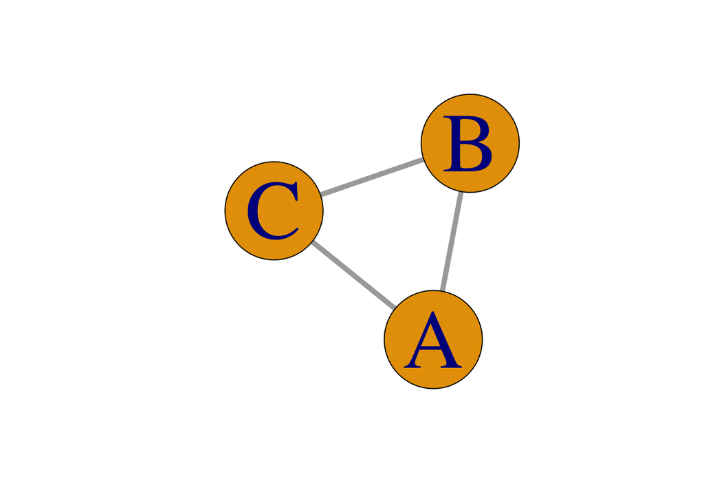

- A, B and C are *nodes* or *vertices* (people, companies, countries etc.)
- Connections are often called *ties* or *edges* (friendship, communication, contracts, kinship etc.)
- Undirected
  $$A \ue B;B \ue C; C \ue A$$

## 2.2 Advantages

- A way of representing a system (social, economic, digital, biological etc.)
- Can help explore and model
  - Properties (Wasserman and Faust 1994)
  - Visualisations (Kerren, Purchase, and Ward 2014)
  - Dynamics (Saavedra, Reed-Tsochas, and Uzzi 2008)
  - Simulations (Bearman, Moody, and Stovel 2004)

## 2.3 Risks

- Complexity and size of data
- Sampling issues: **not law of large numbers** (Browne 2005)
- Pleathora of options
- Causal claims (VanderWeele and An 2013)

# 3 Nodes

## 3.1 Category, Type & Attribute

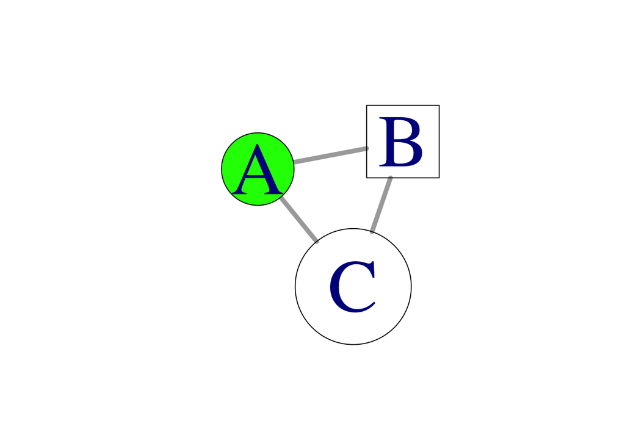

- Category or group (club membership, kinship etc.)
- Type (employee, firm, region etc.)
- Attribute (age, ethnicity, size etc.)

## 3.2 Structure of Romantic and Sexual Relations

- https://github.com/pablobarbera/data-science-workshop/raw/master/sna/data/congress-twitter-network-edges.csv
- https://github.com/pablobarbera/data-science-workshop/raw/master/sna/data/congress-twitter-network-nodes.csv

# 4 Edges

## 4.1 Direction, Weight & Type

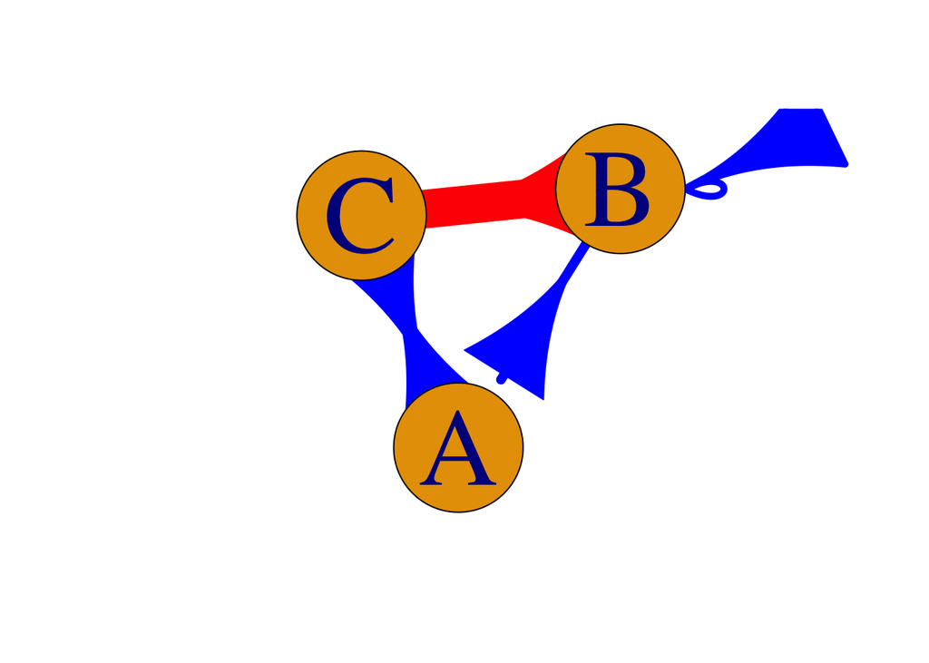

- Direction (transaction, contract, message sender vs reciever etc.)
- Weight (amount of transaction, length of contract, frequency of message etc.)
- Type (type of transaction, cateory, texts vs tweets etc.)
- $A \de B; B \de C; C \leftrightarrow A; B \de B$

## 4.2 Too impressive to be true?

[video not shown]

## 4.3 That’s what lots have said[^1]…

# 5 Types of Nodes

Two types of Nodes (aka Bimodal or Bipartite Networks)

## 5.1 How to enforce different types of nodes

# 6 What else?

## 6.1 There’s lots

- Negative ties (few studies but a recent [*Social Networks* special issue](https://www.sciencedirect.com/journal/social-networks/vol/60))
- [Erdős–Bacon number](https://en.wikipedia.org/wiki/Erd%C5%91s%E2%80%93Bacon_number)

## 6.2 Useful links

- Most of this comes from/is inspired by Katherine Ognyanova’s
- [**Brilliant** visualisation guide](http://www.kateto.net/wp-content/uploads/2019/06/Sunbelt%202019%20R%20Network%20Visualization%20Workshop.pdf)
- Excellent github repo https://github.com/kateto/R-Network-Visualization-Workshop
- A bunch of useful links to papers/software etc. https://github.com/briatte/awesome-network-analysis

# 7 Thanks

# 8 Appendices

## 8.1 Network Analysis Packages

- R
  - [iGraph](https://igraph.org/r/) built on a C++ library, easier to get started and pre-dates ggplot so provides it’s own visualisation options
  - [statnet](http://statnet.org/) focused particularly on [exponential random graphs (ERG) models](https://en.wikipedia.org/wiki/Exponential_random_graph_models), maintained by [Prof Carter T. Butts](https://scholar.google.co.uk/citations?user=-VGAs1cAAAAJ&hl=en)
  - [ggraph](https://ggraph.data-imaginist.com/) network visualisation in a way similar to [ggplot](https://ggplot2.tidyverse.org/reference/ggplot.html), maintained by [Thomas D Pedersen](https://www.data-imaginist.com/)
  - [Rsiena](https://www.stats.ox.ac.uk/~snijders/siena/) Actor-oriented logitudinal models (ERG), created by [Tom Snijders](https://cran.r-project.org/web/packages/RSiena/index.html)
- Python (my language of choice)
  - [networkx](https://networkx.github.io/) very old, not very fast but very flexible (my package of choice for ideas)
  - [igraph](https://igraph.org/python/) Effectively the same as the R package (both use the same underlying C++ library)
  - [graph-tool](https://graph-tool.skewed.de/) Much newer, very speed efficient (also C++ underneath)
- Windows
  - [UCINET](https://sites.google.com/site/ucinetsoftware/home) windows, developed and maintaied by (people including head of group at Manchester)

## References

Bearman, Peter S., James Moody, and Katherine Stovel. 2004. “Chains of Affection: The Structure of Adolescent Romantic and Sexual Networks.” *American Journal of Sociology* 110 (1): 44–91. doi:10.1086/386272.

Browne, Kath. 2005. “Snowball Sampling: Using Social Networks to Research Non-Heterosexual Women.” *International Journal of Social Research Methodology* 8 (1): 47–60. doi:10.1080/1364557032000081663.

Christakis, Nicholas A., and James H. Fowler. 2013. “Social Contagion Theory: Examining Dynamic Social Networks and Human Behavior.” *Statistics in Medicine* 32 (4): 556–77. doi:10.1002/sim.5408.

Cohen-Cole, Ethan, and Jason M. Fletcher. 2008. “Is Obesity Contagious? Social Networks Vs. Environmental Factors in the Obesity Epidemic.” *Journal of Health Economics* 27 (5): 1382–7. doi:10.1016/j.jhealeco.2008.04.005.

Heath, Sue, Alison Fuller, and Brenda Johnston. 2009. “Chasing Shadows: Defining Network Boundaries in Qualitative Social Network Analysis.” *Qualitative Research* 9 (5). SAGE Publications: 645–61. doi:10.1177/1468794109343631.

Kerren, Andreas, Helen Purchase, and Matthew O. Ward, eds. 2014. *Multivariate Network Visualization: Dagstuhl Seminar # 13201, Dagstuhl Castle, Germany, May 12-17, 2013, Revised Discussions*. Information Systems and Applications, Incl. Internet/Web, and HCI, Lect.Notes ComputerState-of-the-Art Surveys. Springer International Publishing. doi:10.1007/978-3-319-06793-3.

Mercken, L., T. A. B. Snijders, C. Steglich, E. Vartiainen, and H. de Vries. 2010. “Dynamics of Adolescent Friendship Networks and Smoking Behavior.” *Social Networks* 32 (1): 72–81. doi:10.1016/j.socnet.2009.02.005.

Murthy, Dhiraj. 2012. “Towards a Sociological Understanding of Social Media: Theorizing Twitter.” *Sociology* 46 (6). SAGE Publications Ltd: 1059–73. doi:10.1177/0038038511422553.

Noel, Hans, and Brendan Nyhan. 2011. “The ‘Unfriending’ Problem: The Consequences of Homophily in Friendship Retention for Causal Estimates of Social Influence.” *Social Networks* 33 (3): 211–18. doi:10.1016/j.socnet.2011.05.003.

Saavedra, Serguei, Felix Reed-Tsochas, and Brian Uzzi. 2008. “Asymmetric Disassembly and Robustness in Declining Networks.” *Proceedings of the National Academy of Sciences* 105 (43): 16466–71. doi:10.1073/pnas.0804740105.

Shalizi, Cosma Rohilla, and Andrew C. Thomas. 2011. “Homophily and Contagion Are Generically Confounded in Observational Social Network Studies.” *Sociological Methods & Research* 40 (2): 211–39. doi:10.1177/0049124111404820.

Tero, Atsushi, Seiji Takagi, Tetsu Saigusa, Kentaro Ito, Dan P. Bebber, Mark D. Fricker, Kenji Yumiki, Ryo Kobayashi, and Toshiyuki Nakagaki. 2010. “Rules for Biologically Inspired Adaptive Network Design.” *Science* 327 (5964). American Association for the Advancement of Science: 439–42. doi:10.1126/science.1177894.

VanderWeele, Tyler J., and Weihua An. 2013. “Social Networks and Causal Inference.” In *Handbook of Causal Analysis for Social Research*, edited by Stephen L. Morgan, 353–74. Handbooks of Sociology and Social Research. Dordrecht: Springer Netherlands. doi:10.1007/978-94-007-6094-3_17.

Wasserman, Stanley, and Katherine Faust. 1994. *Social Network Analysis: Methods and Applications (Structural Analysis in the Social Sciences)*. 1st ed. Structural Analysis in the Social Sciences, 8. Cambridge University Press. http://www.worldcat.org/isbn/0521387078.

[^1]: See https://statmodeling.stat.columbia.edu/2011/06/10/christakis-fowl/ for a summary
[^2]: Full disclosure: one of my examiners was a co-author on one of these papers…